# Projet séries temporelles

MAHAMAT HASSAN ISSA

2023-05-30

```r
# On regarde les données sncf
View(sncf)
summary(sncf)
```

```
##      ANNEE         JANVIER        FEVRIER          MARS          AVRIL
##  Min.   :1963   Min.   :1670   Min.   :1560   Min.   :1770   Min.   :1990
##  1st Qu.:1967   1st Qu.:1816   1st Qu.:1678   1st Qu.:1865   1st Qu.:2151
##  Median :1972   Median :2044   Median :1942   Median :2136   Median :2470
##  Mean   :1972   Mean   :2195   Mean   :2101   Mean   :2309   Mean   :2555
##  3rd Qu.:1976   3rd Qu.:2620   3rd Qu.:2546   3rd Qu.:2746   3rd Qu.:2894
##  Max.   :1980   Max.   :3313   Max.   :2913   Max.   :3306   Max.   :3333
##       MAI            JUIN         JUILLET          AOUT        SEPTEMBRE
##  Min.   :1910   Min.   :2175   Min.   :2581   Min.   :2639   Min.   :1932
##  1st Qu.:2111   1st Qu.:2486   1st Qu.:2939   1st Qu.:2762   1st Qu.:2143
##  Median :2272   Median :2703   Median :3165   Median :2880   Median :2228
##  Mean   :2489   Mean   :2888   Mean   :3249   Mean   :2928   Mean   :2426
##  3rd Qu.:2931   3rd Qu.:3394   3rd Qu.:3636   3rd Qu.:3084   3rd Qu.:2820
##  Max.   :3391   Max.   :3682   Max.   :3937   Max.   :3284   Max.   :3206
##     OCTOBRE        NOVEMBRE       DECEMBRE
##  Min.   :1850   Min.   :1630   Min.   :2270
##  1st Qu.:1937   1st Qu.:1774   1st Qu.:2445
##  Median :2144   Median :1994   Median :2638
##  Mean   :2359   Mean   :2205   Mean   :2861
##  3rd Qu.:2790   3rd Qu.:2677   3rd Qu.:3297
##  Max.   :3269   Max.   :3181   Max.   :4008
```

Pas de données maquantes ni incoherentes

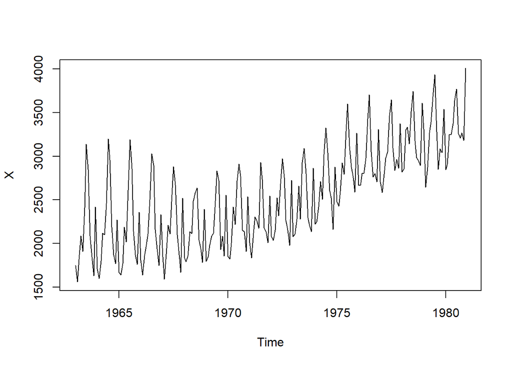

```r
plot(X,ylab="X")
```

la serie semble avoir une tendance qui augmente.

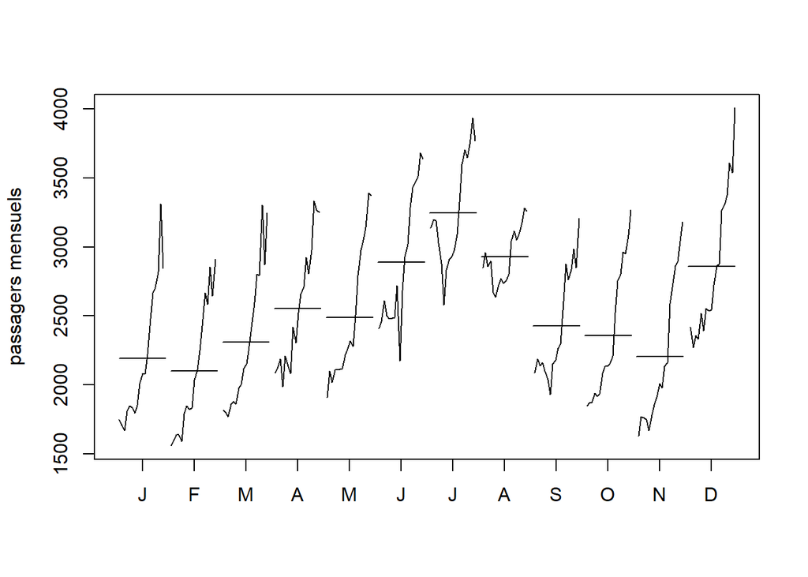

```r
monthplot(X,ylab="passagers mensuels")
```

En l’absence d’effet saisonnier, les 12 chronogrammes mensuels seraient à peu près identiques, ce qui n’est pas le cas ici. On remarque notamment un interet pour le mot-clef plus fort en été et Décembre (périodes des vacances scolaires).Le nombre de passager augmente durant les vacances scolaires.

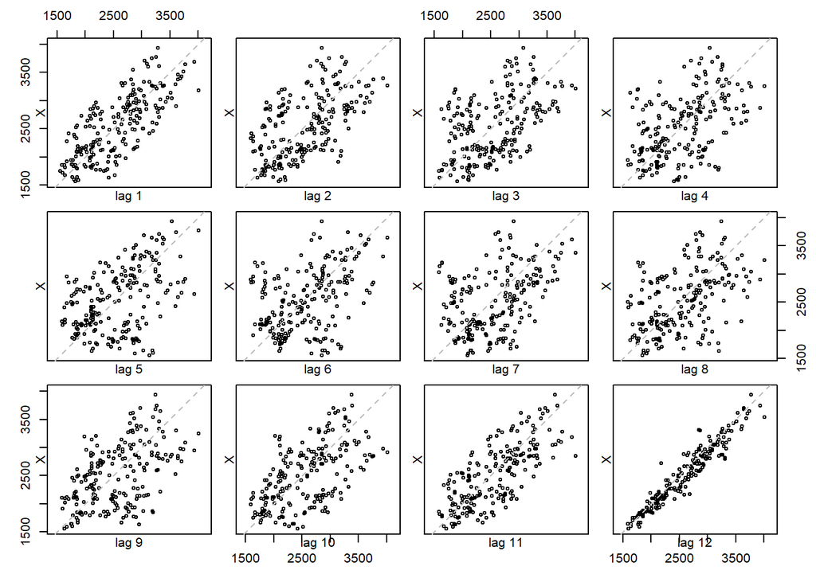

```r
lag.plot(X,lags=12,layout=c(3,4),do.lines=FALSE)
```

En observant un lag de 12 mois,on vois l’influence du passé sur la série.

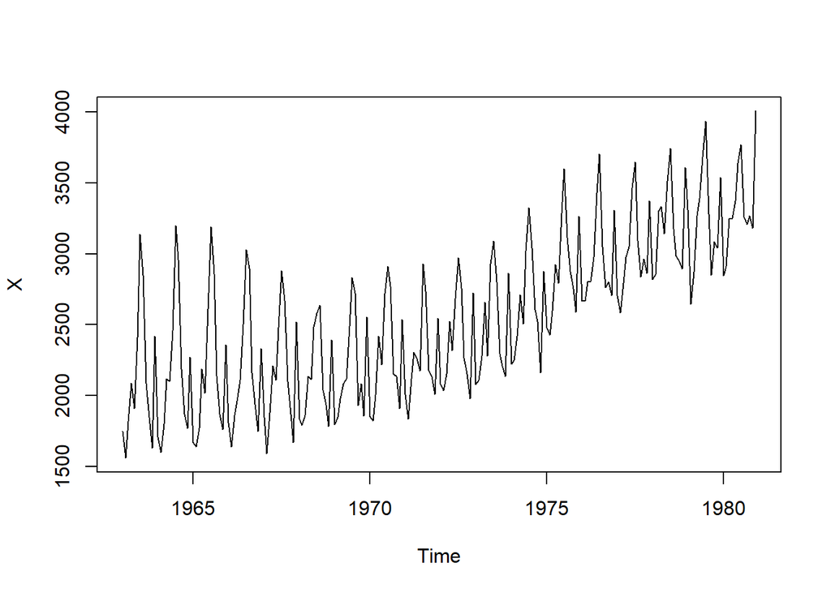

```r
# La série est elle Additive ou Multiplicative ?

# Tout d’abord reprenons le graphe.
plot(X,ylab="X")
```

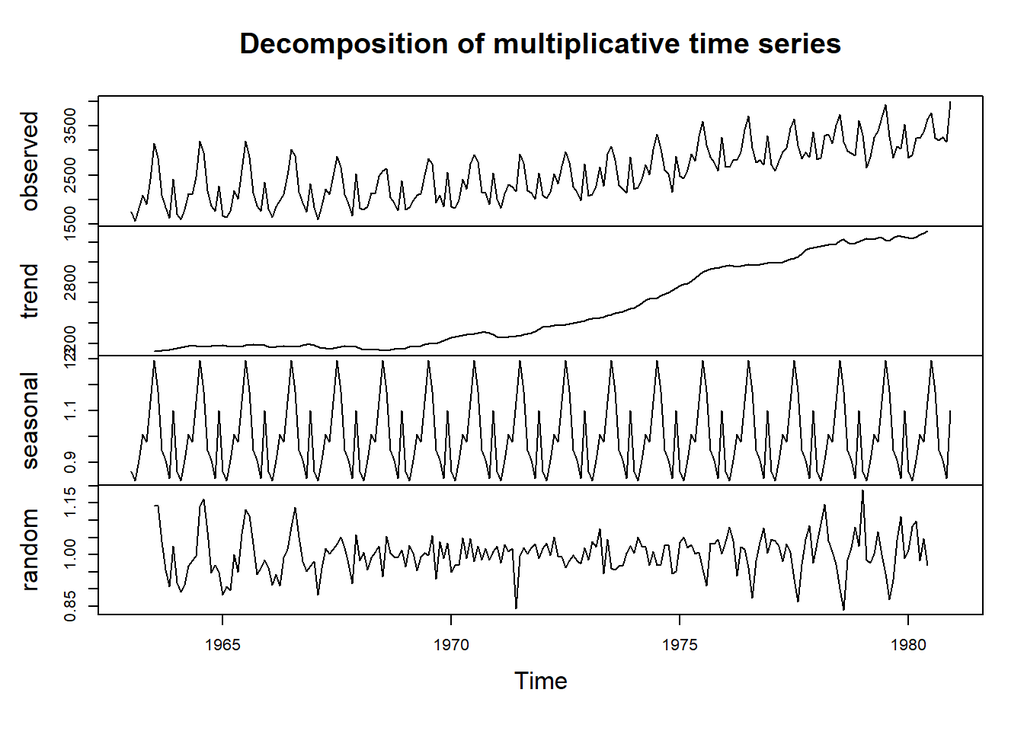

```r
decompose_X = decompose(X, "multiplicative")
plot(decompose_X)
```

```r
Box.test(X,lag=20,type="Box-Pierce")
```

```
##
##  Box-Pierce test
##
## data:  X
## X-squared = 1089.9, df = 20, p-value < 2.2e-16
```

p-value inferieur à 5%, on rejette H0 donc on est pas en presence d’un bruit blanc.

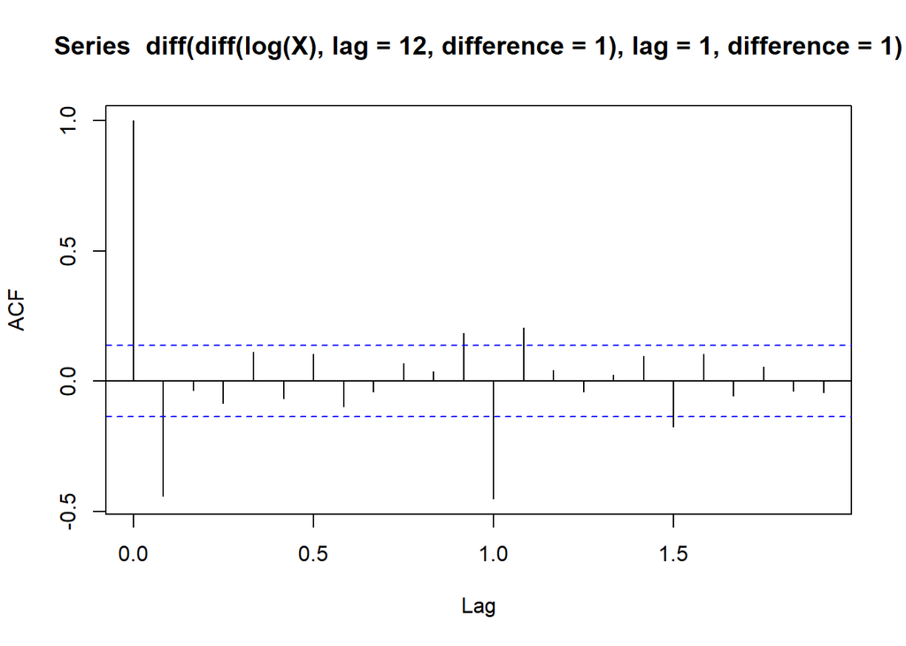

```r
#  Modélisation

# Analyse des Corrélations

# On affiche le graphique ACF pour rechercher le coéfficient AR
acf(diff(diff(log(X),lag=12,difference=1),lag=1,difference=1))
```

ainsi en aplliquant le critère vu en cours, on choisit p=1

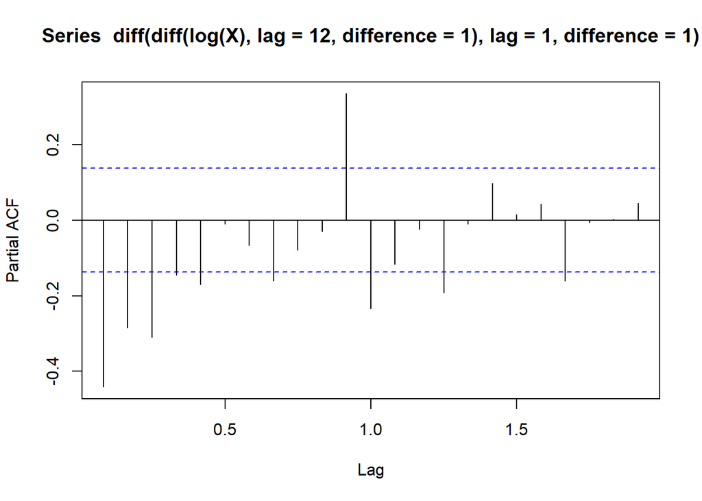

```r
# On affiche le graphique PACF pour rechercher le coéfficient MA
pacf(diff(diff(log(X),lag=12,difference=1),lag=1,difference=1))
```

ainsi en aplliquant le critère vu en cours, on choisit q=1

```r
# Choix du Modèle Manuellement
md1=arima(diff(diff(log(X),lag=1,difference=1),lag=1,difference=1),order=c(1,0,1))
t_stat(md1)
```

```
##              ar1       ma1 intercept
## t.stat -2.424902 -85.62507  0.064286
## p.val   0.015312   0.00000  0.948743
```

Les valeurs des test ne confirme qu’il faut changer l’ordre.

Choix avec d’autres coefficient. Apres avoir chercher de façon empirique, voici le meilleur modèle ARMA en manuel. Ce modèle à le meilleur compromis entre la simplicité et les résultats au test.

```r
md2=arima(diff(diff(log(X),lag=1,difference=1),lag=1,difference=1),order=c(3,0,1))
```

On peut regarder la matrice de correlations des estimateurs.

```r
cor.arma(md2)
```

```
##                     ar1           ar2           ar3           ma1     intercept
## ar1        1.000000e+00  2.002232e-01  1.852890e-01 -3.269522e-07  1.516138e-02
## ar2        2.002232e-01  1.000000e+00  2.003658e-01 -2.725740e-07  7.311459e-03
## ar3        1.852890e-01  2.003658e-01  1.000000e+00 -2.114444e-07  1.902618e-03
## ma1       -3.269522e-07 -2.725740e-07 -2.114444e-07  1.000000e+00 -2.073271e-06
## intercept  1.516138e-02  7.311459e-03  1.902618e-03 -2.073271e-06  1.000000e+00
```

Tous les coéfficients sont bien inferieurs à 0.9

```r
t_stat(md2)
```

```
##              ar1       ar2       ar3       ma1 intercept
## t.stat -3.586708 -3.414976 -3.599056 -84.42742  0.056132
## p.val   0.000335  0.000638  0.000319   0.00000  0.955237
```

Les coéfficients ont une p.val faible.

```r
summary(md2)
```

```
##
## Call:
## arima(x = diff(diff(log(X), lag = 1, difference = 1), lag = 1, difference = 1),
##     order = c(3, 0, 1))
##
## Coefficients:
##           ar1      ar2      ar3      ma1  intercept
##       -0.2391  -0.2281  -0.2396  -1.0000      0e+00
## s.e.   0.0667   0.0668   0.0666   0.0118      1e-04
##
## sigma^2 estimated as 0.02202:  log likelihood = 101.26,  aic = -190.52
##
## Training set error measures:
##                        ME      RMSE       MAE      MPE     MAPE      MASE
## Training set -0.003190166 0.1484081 0.1247135 8.572188 198.7046 0.3883776
##                    ACF1
## Training set 0.01059991
```

AIC =-190

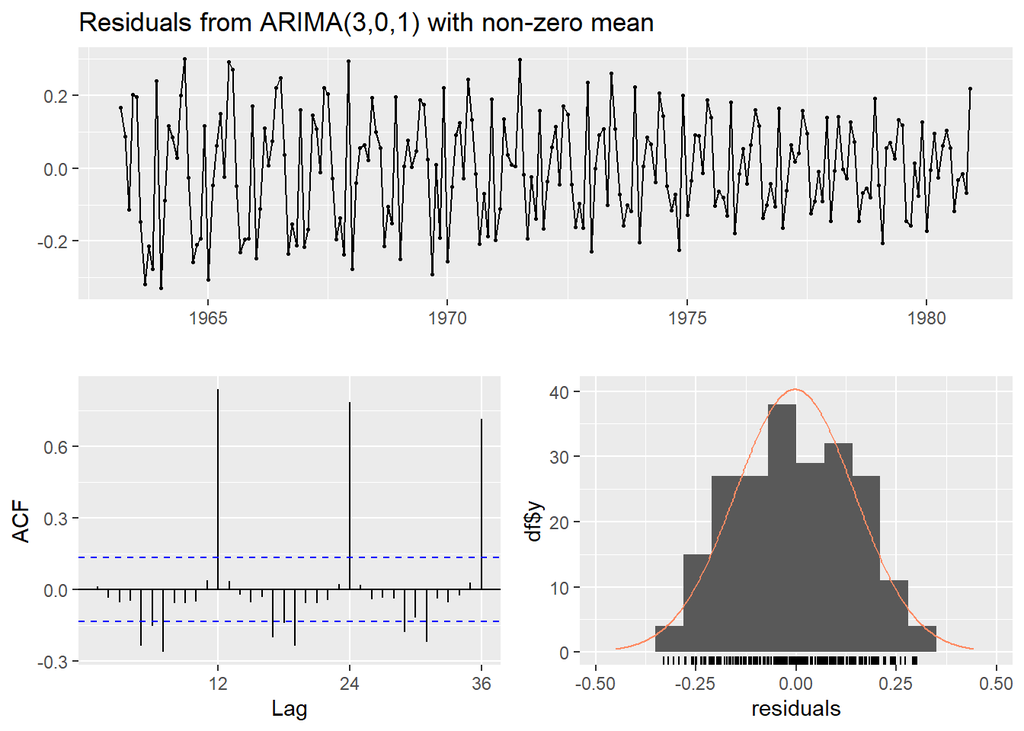

```
##
##  Ljung-Box test
##
## data:  Residuals from ARIMA(3,0,1) with non-zero mean
## Q* = 378.64, df = 20, p-value < 2.2e-16
##
## Model df: 4.   Total lags used: 24
```

```r
checkresiduals(md2)
```

```r
## Modele Auto Arima

# On peut sélectionner un modèle automatique de 2 façons : Premièrement avec la fonction armaselect
armaselect(diff(diff(log(X),lag=12,difference=1),lag=1,
                difference=1))
```

```
##        p  q       sbc
##  [1,] 15  0 -1150.815
##  [2,] 12  0 -1150.277
##  [3,] 13  0 -1149.574
##  [4,]  0 13 -1145.498
##  [5,] 14  0 -1144.649
##  [6,] 12  1 -1143.524
##  [7,]  2 12 -1142.869
##  [8,]  2 13 -1142.462
##  [9,]  1 13 -1141.332
## [10,]  0 14 -1141.305
```

Ou avec la fonction auto.arima

```r
mda=auto.arima(diff(diff(log(X),lag=12,difference=1),lag=1,
                    difference=1))
summary(mda)
```

```
## Series: diff(diff(log(X), lag = 12, difference = 1), lag = 1, difference = 1)
## ARIMA(1,0,3)(0,0,2)[12] with zero mean
##
## Coefficients:
##           ar1     ma1      ma2      ma3     sma1    sma2
##       -0.8144  0.1049  -0.6525  -0.2062  -0.5937  0.1419
## s.e.   0.1281  0.1404   0.1120   0.0754   0.0758  0.0744
##
## sigma^2 = 0.002374:  log likelihood = 325.48
## AIC=-636.96   AICc=-636.38   BIC=-613.77
##
## Training set error measures:
##                       ME       RMSE        MAE       MPE     MAPE      MASE
## Training set 0.001728101 0.04800068 0.03713941 -3.935493 296.2438 0.4142767
##                      ACF1
## Training set -0.008682619
```

AIC=-637

on obseve les résidus.

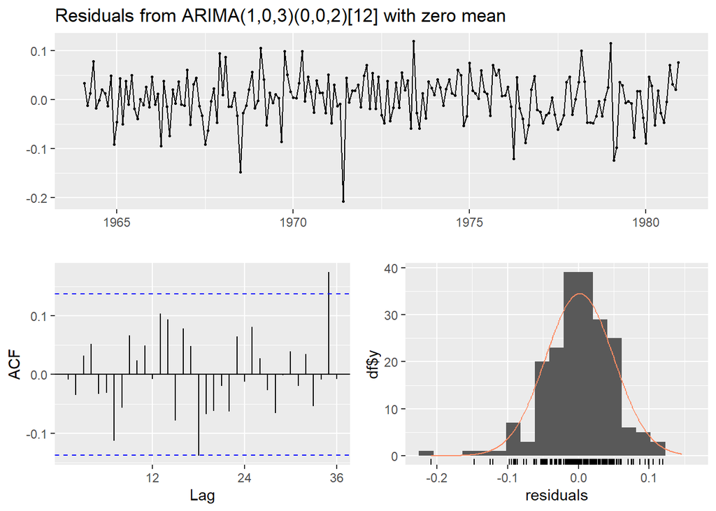

```
##
##  Ljung-Box test
##
## data:  Residuals from ARIMA(1,0,3)(0,0,2)[12] with zero mean
## Q* = 22.242, df = 18, p-value = 0.2214
##
## Model df: 6.   Total lags used: 24
```

```r
checkresiduals(mda)
```

Le modèle semble être cohérent. Les résidus semblent se comporter comme un bruit blanc gaussien. Cependant le test de Ljung-Box test à une p-value de 0.22 essayons d’améliorer ce résultat. Pour se faire essayons de modéliser la série à l’aide d’un modèle SARMA.

## Modèle Auto SARMA

Nous recherchons par la suite un modèle SARIMA en mode automatique. #Pour cela on conserve la saisonnalité et on applique la fonction Auto.arima .

```r
mdsa=auto.arima(diff(log(X),lag=1, difference=1))
summary(mdsa)
```

```
## Series: diff(log(X), lag = 1, difference = 1)
## ARIMA(1,0,3)(0,1,2)[12]
##
## Coefficients:
##           ar1     ma1      ma2      ma3     sma1    sma2
##       -0.8144  0.1049  -0.6525  -0.2062  -0.5937  0.1419
## s.e.   0.1281  0.1404   0.1120   0.0754   0.0758  0.0744
##
## sigma^2 = 0.002374:  log likelihood = 325.48
## AIC=-636.96   AICc=-636.38   BIC=-613.77
##
## Training set error measures:
##                       ME       RMSE        MAE      MPE    MAPE      MASE
## Training set 0.001631537 0.04664192 0.03507763 -89.9094 210.333 0.6466543
##                      ACF1
## Training set -0.008773206
```

AIC=-637

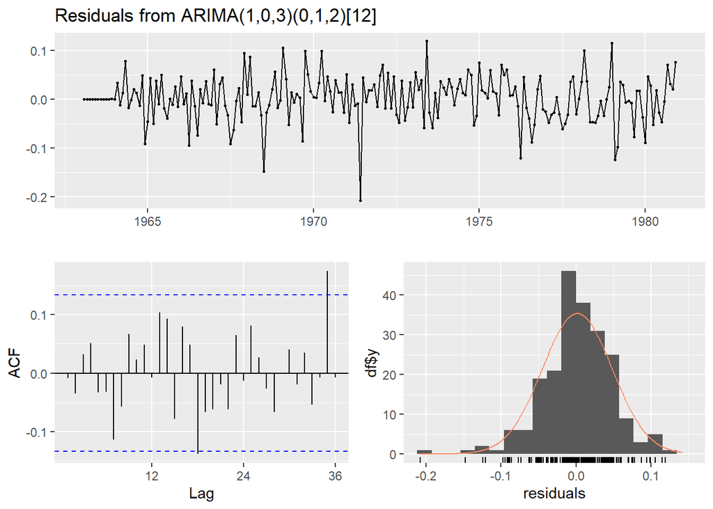

```
##
##  Ljung-Box test
##
## data:  Residuals from ARIMA(1,0,3)(0,1,2)[12]
## Q* = 23.439, df = 18, p-value = 0.1743
##
## Model df: 6.   Total lags used: 24
```

```r
checkresiduals(mdsa)
```

Le modèle semble être cohérent. Les résidus semblent se comporter comme un bruit blanc gaussien Cependant le test de Ljung-Box test à une p-value de 0.17.

```r
X6379=window(X,start=1963,end=c(1979,12))
X6379
```

```
##       Jan  Feb  Mar  Apr  May  Jun  Jul  Aug  Sep  Oct  Nov  Dec
## 1963 1750 1560 1820 2090 1910 2410 3140 2850 2090 1850 1630 2420
## 1964 1710 1600 1800 2120 2100 2460 3200 2960 2190 1870 1770 2270
## 1965 1670 1640 1770 2190 2020 2610 3190 2860 2140 1870 1760 2360
## 1966 1810 1640 1860 1990 2110 2500 3030 2900 2160 1940 1750 2330
## 1967 1850 1590 1880 2210 2110 2480 2880 2670 2100 1920 1670 2520
## 1968 1834 1792 1860 2138 2115 2485 2581 2639 2038 1936 1784 2391
## 1969 1798 1850 1981 2085 2120 2491 2834 2725 1932 2085 1856 2553
## 1970 1854 1823 2005 2418 2219 2722 2912 2771 2153 2136 1910 2537
## 1971 2008 1835 2120 2304 2264 2175 2928 2738 2178 2137 2009 2546
## 1972 2084 2034 2152 2522 2318 2684 2971 2759 2267 2152 1978 2723
## 1973 2081 2112 2279 2661 2281 2929 3089 2803 2296 2210 2135 2862
## 1974 2223 2248 2421 2710 2505 3021 3327 3044 2607 2525 2160 2876
## 1975 2481 2428 2596 2923 2795 3287 3598 3118 2875 2754 2588 3266
## 1976 2667 2668 2804 2806 2976 3430 3705 3053 2764 2802 2707 3307
## 1977 2706 2586 2796 2978 3053 3463 3649 3095 2839 2966 2863 3375
## 1978 2820 2857 3306 3333 3141 3512 3744 3179 2984 2950 2896 3611
## 1979 3313 2644 2872 3267 3391 3682 3937 3284 2849 3085 3043 3541
```

```r
X80=window(X,start=1980)
X80
```

```
##       Jan  Feb  Mar  Apr  May  Jun  Jul  Aug  Sep  Oct  Nov  Dec
## 1980 2848 2913 3248 3250 3375 3640 3771 3259 3206 3269 3181 4008
```

## Prédiction avec le modèle ARMA

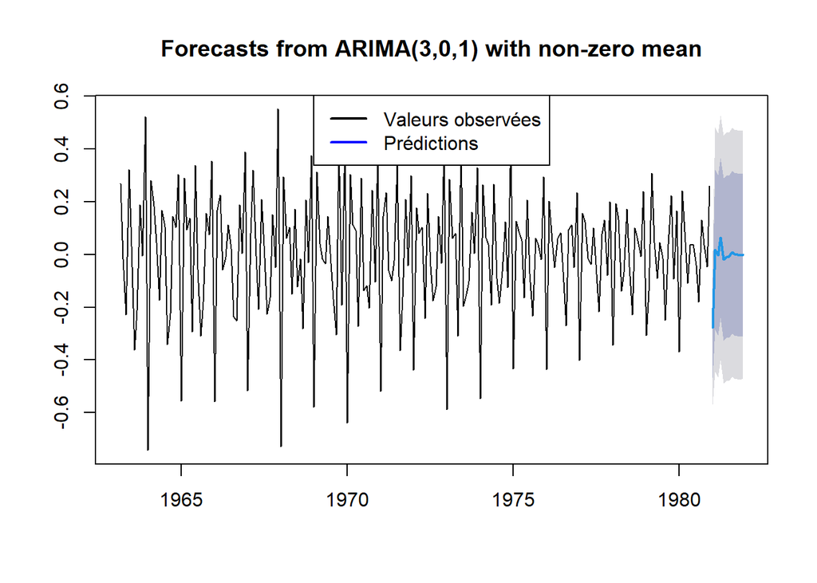

```r
fc2=forecast(md2, h = 12)
plot(fc2)
points(X80,type="l",col="darkgreen",lwd=2)
legend("top",c("Valeurs observées","Prédictions"),col=c("black","blue"),lty=rep(1,2),lwd = rep(2,2))
```

Nous observons la prévision sur 1 an avec un seuil à 95% et 80%.

## Prédiction avec le modèle SARMA

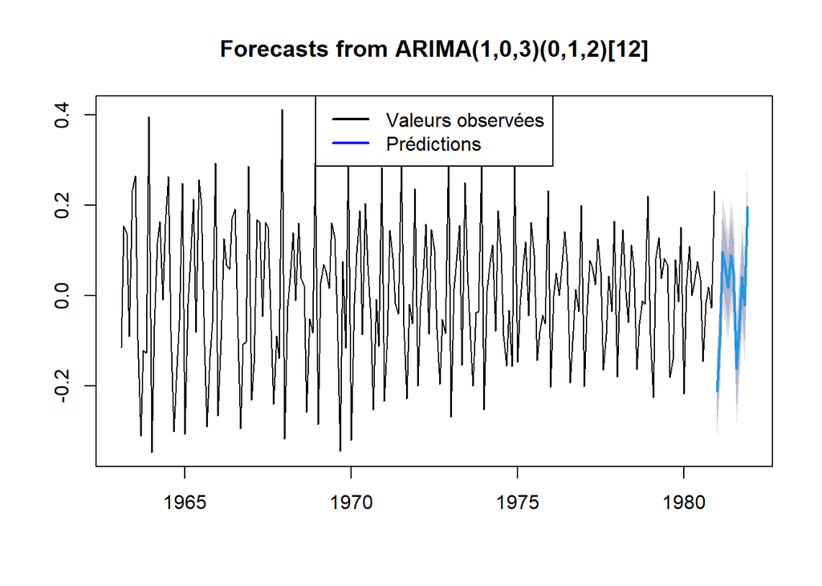

```r
fcsa=forecast(mdsa, h = 12)
plot(fcsa)
points(X80,type="l",col="darkgreen",lwd=2)
legend("top",c("Valeurs observées","Prédictions"),col=c("black","blue"),lty=rep(1,2),lwd = rep(2,2))
```

Nous observons la prévision sur 1 an avec un seuil à 95% et 80%.

## Conclusion

Cette étude fu très intéressante nous avons dû retravailler la série notamment en la transformant afin de supprimer les effets de saisonnalité.